# 生存分析前的数据整理

与上课代码的主要区别：

1.使用了TPM而非CPM 2.有TNM信息的拆分

表达矩阵只需要tumor数据，不要normal，将其去掉，新表达矩阵数据命名为exprSet；

临床信息需要进一步整理，成为生存分析需要的格式，新临床信息数据命名为meta。

由于不同癌症的临床信息表格列名可能不同，这里的代码需要根据实际情况修改。

```r
rm(list=ls())
proj = "TCGA-STAD"
load(paste0("../2_tcga_stad/",proj,".Rdata"))
library(stringr)
```

### 1.整理表达矩阵

#### 1.1去除normal样本

```r
table(Group)
```

```
#> Group
#> normal  tumor
#>     32    375
```

```r
exprSet = exp[,Group=='tumor']
ncol(exp)
```

```
#> [1] 407
```

```r
ncol(exprSet)
```

```
#> [1] 375
```

#### 1.2 基因过滤

再次进行基因过滤.

(1)标准1：至少要在50%的样本里表达量大于0（最低标准）。

exp(600样本)满足“至少在300个样本里表达量>0”,不能等同于 exprSet(500样本)满足“至少在250个样本里表达量>0”

```r
k = apply(exprSet,1, function(x){sum(x>0)>0.5*ncol(exprSet)});table(k)
```

```
#> k
#> FALSE  TRUE
#>    25 37593
```

```r
exprSet = exprSet[k,]
nrow(exprSet)
```

```
#> [1] 37593
```

(2)标准2：至少在一半以上样本里表达量＞10(其他数字也可，酌情调整)

```r
k = apply(exprSet,1, function(x){sum(x>10)>0.5*ncol(exprSet)});table(k)
```

```
#> k
#> FALSE  TRUE
#> 15449 22144
```

```r
exprSet = exprSet[k,]
nrow(exprSet)
```

```
#> [1] 22144
```

#### 1.3 使用logCPM或logTPM数据

这里是用了tmp。

```r
#cpm
#exprSet = log2(edgeR::cpm(exprSet)+1)
#tmp
exprSet[1:4,1:4]
```

```
#>            TCGA-BR-8484-01A-11R-2402-13
#> WASH7P                               72
#> AL627309.6                          100
#> AL627309.7                           99
#> AL627309.5                           19
#>            TCGA-BR-8077-01A-11R-2343-13
#> WASH7P                               58
#> AL627309.6                          112
#> AL627309.7                          124
#> AL627309.5                           39
#>            TCGA-IP-7968-01A-11R-2203-13
#> WASH7P                               71
#> AL627309.6                           31
#> AL627309.7                           44
#> AL627309.5                           26
#>            TCGA-VQ-AA64-01A-11R-A414-31
#> WASH7P                               48
#> AL627309.6                           23
#> AL627309.7                           13
#> AL627309.5                           16
```

```r
load("stad_tpm.Rdata")
stad_tpm[1:4,1:4]
```

```
#>                    TCGA-HU-A4GN-11A-12R-A251-31
#> ENSG00000000003.15                   5.50902013
#> ENSG00000000005.6                    0.02415144
#> ENSG00000000419.13                  75.63654733
#> ENSG00000000457.14                   3.73410807
#>                    TCGA-BR-8484-01A-11R-2402-13
#> ENSG00000000003.15                    30.247017
#> ENSG00000000005.6                      0.163460
#> ENSG00000000419.13                   147.185496
#> ENSG00000000457.14                     9.972461
#>                    TCGA-BR-8077-01A-11R-2343-13
#> ENSG00000000003.15                    84.106474
#> ENSG00000000005.6                      0.000000
#> ENSG00000000419.13                   141.281662
#> ENSG00000000457.14                     4.416763
#>                    TCGA-IP-7968-11A-01R-2203-13
#> ENSG00000000003.15                  50.00835022
#> ENSG00000000005.6                    0.06437034
#> ENSG00000000419.13                  53.64518941
#> ENSG00000000457.14                   2.62959826
```

```r
library(tinyarray)
stad_tpm = trans_exp_new(stad_tpm)
stad_tpm = log2(stad_tpm+1)
stad_tpm = stad_tpm[rownames(exprSet),colnames(exprSet)]
exprSet= stad_tpm
exprSet[1:4,1:4]
```

```
#>            TCGA-BR-8484-01A-11R-2402-13
#> WASH7P                        1.6521458
#> AL627309.6                    2.6612893
#> AL627309.7                    3.9085506
#> AL627309.5                    0.1389103
#>            TCGA-BR-8077-01A-11R-2343-13
#> WASH7P                        1.4542686
#> AL627309.6                    2.8100329
#> AL627309.7                    4.2248111
#> AL627309.5                    0.2739719
#>            TCGA-IP-7968-01A-11R-2203-13
#> WASH7P                        1.7113509
#> AL627309.6                    1.4736193
#> AL627309.7                    2.9459440
#> AL627309.5                    0.2002232
#>            TCGA-VQ-AA64-01A-11R-A414-31
#> WASH7P                        1.2608949
#> AL627309.6                    1.1357597
#> AL627309.7                    1.4849783
#> AL627309.5                    0.1152919
```

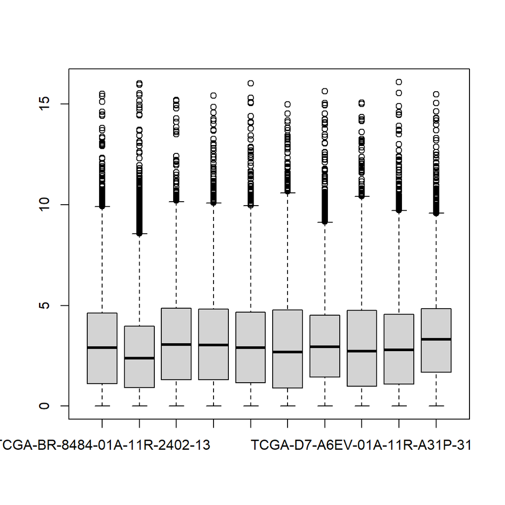

```r
boxplot(exprSet[,1:10])
```

#### 1.4 样本与病人

有的病人会有两个或两个以上的肿瘤样本，就有重复。两种可行的办法：

（1）以病人为中心，对表达矩阵的列按照病人ID去重复，每个病人只保留一个样本。

```r
exprSet = exprSet[,sort(colnames(exprSet))]
k = !duplicated(str_sub(colnames(exprSet),1,12));table(k)
```

```
#> k
#> TRUE
#>  375
```

```r
exprSet = exprSet[,k]
ncol(exprSet)
```

```
#> [1] 375
```

（2）以样本为中心，如果每个病人有多个样本则全部保留。(删掉上面这一段代码即可)

### 2.整理生存信息和临床信息

#### 2.1数据合并

xena单独整理了生存信息，把它和临床信息合并到一起。

```r
library(dplyr)
surv = read.delim("TCGA-STAD.survival.tsv")
meta = left_join(surv,clinical,by = c("X_PATIENT"= "bcr_patient_barcode"))
nrow(meta)
```

```
#> [1] 514
```

```r
length(unique(meta$sample))
```

```
#> [1] 502
```

```r
meta = distinct(meta,sample,.keep_all = T)
```

#### 2.2 样本过滤

去掉生存信息不全或者生存时间小于30天的样本，样本纳排标准不唯一，且差别很大

```r
k1 = meta$OS.time >= 30;table(k1)
```

```
#> k1
#> FALSE  TRUE
#>    21   481
```

```r
k2 = !(is.na(meta$OS.time)|is.na(meta$OS));table(k2)
```

```
#> k2
#> TRUE
#>  502
```

```r
meta = meta[k1&k2,]
```

#### 2.3 选列、简化列名

小技巧：搜索列名

```r
tmp = data.frame(colnames(meta))
#View(tmp)
```

选择需要的列，简化列名

```r
meta = meta[,c(
  'sample',
  'OS',
  'OS.time',
  'race_list',
  'age_at_initial_pathologic_diagnosis',
  'gender' ,
  'stage_event_pathologic_stage',
  'stage_event_tnm_categories'
)]
colnames(meta)=c('ID','event','time','race','age','gender','stage','TNM')
str(meta)
```

```
#> 'data.frame':    481 obs. of  8 variables:
#>  $ ID    : chr  "TCGA-CG-5722-01A" "TCGA-CG-5722-11A" "TCGA-CG-5720-01A" "TCGA-CG-5720-11A" ...
#>  $ event : int  0 0 1 1 0 0 0 1 0 0 ...
#>  $ time  : int  30 30 30 30 31 34 35 45 46 46 ...
#>  $ race  : Factor w/ 5 levels "","ASIAN","BLACK OR AFRICAN AMERICAN",..: 1 1 1 1 1 5 5 5 2 2 ...
#>  $ age   : int  67 67 71 71 54 64 72 77 56 56 ...
#>  $ gender: Factor w/ 2 levels "FEMALE","MALE": 1 1 2 2 1 1 2 2 2 2 ...
#>  $ stage : Factor w/ 12 levels "","Stage I","Stage IA",..: 12 12 4 4 12 6 10 11 1 1 ...
#>  $ TNM   : Factor w/ 76 levels "T1aN0M0","T1bN0M0",..: 34 34 18 18 65 28 46 61 27 27 ...
```

```r
meta$gender = as.character(meta$gender)
meta$stage = as.character(meta$stage)
meta$race = as.character(meta$race)
meta$TNM = as.character(meta$TNM)
```

#### 2.4 简化、规范内容

1. 结局事件

生存分析的输入数据里，要求结局事件必须用0和1表示，1表示阳性结局。

xena的数据是整理好的，其他来源的需要自行检查和整理。

```r
table(meta$event)
```

```
#>
#>   0   1
#> 281 200
```

```r
#自行整理的例子：
a = c("Dead", "Dead", "Alive", "Dead", "Alive")
ifelse(a=="Alive",0,1)
```

```
#> [1] 1 1 0 1 0
```

2. 生存时间

认清生存时间的单位（通常是月，也可以用天和年）;

```r
range(meta$time)
```

```
#> [1]   30 3720
```

```r
meta$time = meta$time/30
range(meta$time)
```

```
#> [1]   1 124
```

(3)检查各列的信息是否规范

没有冗余信息

缺失的信息用NA代替

```r
meta[meta==""] = NA
table(meta$stage)
```

```
#>
#>    Stage I   Stage IA   Stage IB   Stage II  Stage IIA
#>          1         20         45         38         50
#>  Stage IIB  Stage III Stage IIIA Stage IIIB Stage IIIC
#>         71          4         84         65         34
#>   Stage IV
#>         45
```

```r
meta$stage = meta$stage %>%
  str_remove_all("Stage |A|B|C")
table(meta$stage,useNA = "always")
```

```
#>
#>    I   II  III   IV <NA>
#>   66  159  187   45   24
```

```r
table(meta$race,useNA = "always")
```

```
#>
#>                                     ASIAN
#>                                       101
#>                 BLACK OR AFRICAN AMERICAN
#>                                        15
#> NATIVE HAWAIIAN OR OTHER PACIFIC ISLANDER
#>                                         1
#>                                     WHITE
#>                                       298
#>                                      <NA>
#>                                        66
```

```r
table(meta$gender,useNA = "always")
```

```
#>
#> FEMALE   MALE   <NA>
#>    169    312      0
```

# tnm拆分

```r
#特殊情况：没有N的，手动加上NX
table(meta$TNM %>% str_detect("N"))
```

```
#>
#> FALSE  TRUE
#>     3   478
```

```r
n = which(! meta$TNM %>% str_detect("N"))
meta$TNM[n]
```

```
#> [1] "T3M0" "T3M0" "T4M0"
```

```r
meta$TNM[n] =c("T3NXM0", "T3NXM0", "T4NXM0")

tnm = meta$TNM %>%
  str_remove_all("a|b|c") %>%
  str_split("T|N|M",simplify = T) %>%
  as.data.frame() %>% select(-1)
head(tnm)
```

```
#>   V2 V3 V4
#> 1  3  2  1
#> 2  3  2  1
#> 3  2  0  0
#> 4  2  0  0
#> 5  4  0  1
#> 6  3  0  0
```

```r
colnames(tnm) = c("T","N","M")
table(tnm$M,useNA = "always")
```

```
#>
#>    0    1    X <NA>
#>  430   30   21    0
```

```r
tnm = apply(tnm,2,as.numeric) # 转换数值型，X无法转换，正好变成NA
meta = cbind(meta[,-8],tnm)
```

```r
str(meta)
```

```
#> 'data.frame':    481 obs. of  10 variables:
#>  $ ID    : chr  "TCGA-CG-5722-01A" "TCGA-CG-5722-11A" "TCGA-CG-5720-01A" "TCGA-CG-5720-11A" ...
#>  $ event : int  0 0 1 1 0 0 0 1 0 0 ...
#>  $ time  : num  1 1 1 1 1.03 ...
#>  $ race  : chr  NA NA NA NA ...
#>  $ age   : int  67 67 71 71 54 64 72 77 56 56 ...
#>  $ gender: chr  "FEMALE" "FEMALE" "MALE" "MALE" ...
#>  $ stage : chr  "IV" "IV" "I" "I" ...
#>  $ T     : num  3 3 2 2 4 3 4 4 3 3 ...
#>  $ N     : num  2 2 0 0 0 0 2 3 NA NA ...
#>  $ M     : num  1 1 0 0 1 0 0 0 0 0 ...
```

### 3.实现表达矩阵与临床信息的匹配

即：meta的每一行与exprSet每一列一一对应

```r
rownames(meta) <- meta$ID
head(rownames(meta))
```

```
#> [1] "TCGA-CG-5722-01A" "TCGA-CG-5722-11A" "TCGA-CG-5720-01A"
#> [4] "TCGA-CG-5720-11A" "TCGA-CG-5719-01A" "TCGA-BR-8487-01A"
```

```r
head(colnames(exprSet))
```

```
#> [1] "TCGA-3M-AB46-01A-11R-A414-31"
#> [2] "TCGA-3M-AB47-01A-22R-A414-31"
#> [3] "TCGA-B7-5818-01A-11R-1602-13"
#> [4] "TCGA-B7-A5TI-01A-11R-A31P-31"
#> [5] "TCGA-B7-A5TJ-01A-11R-A31P-31"
#> [6] "TCGA-B7-A5TK-01A-12R-A36D-31"
```

```r
colnames(exprSet) = str_sub(colnames(exprSet),1,16)
s = intersect(rownames(meta),colnames(exprSet));length(s)
```

```
#> [1] 337
```

```r
exprSet = exprSet[,s]
meta = meta[s,]
dim(exprSet)
```

```
#> [1] 22144   337
```

```r
dim(meta)
```

```
#> [1] 337  10
```

```r
identical(rownames(meta),colnames(exprSet))
```

```
#> [1] TRUE
```

```r
save(meta,exprSet,proj,file = paste0(proj,"_sur_model.Rdata"))
```